# GenEst - 1. A Tutorial with Wind Examples

Daniel Dalthorp

2023-05-25

## Introduction: Tutorial with Examples

This tutorial provides an introduction to the array of command line tools **GenEst** (1.4.9) provides for estimating bird and/or bat mortality and detection probabilities and wind power facilities. The approach is to walk through analyses of realistic but simulated data sets representing studies of bird and bat mortality at a wind power facilities.

The general steps in the analysis are:

1. Construct a model for Searcher Efficiency
2. Construct a model for Carcass Persistance
3. Estimate mortality
4. Specify the type of summary desired (e.g., mortality by species and season)

Data required for a full analysis include results of searcher efficiency trials, results of carcass persistence trials, search schedules for all units searched, the search coverage within each unit, and results of periodic carcass surveys. More information about the kinds of data required can be found in the User Guide, which can be found at `https://code.usgs.gov/ecosystems/GenEst/-/releases` in the “For more info” section. For convenience, data required in this tutorial are available in R as packaged lists, which can readily be loaded as described below. Alternatively, the data may be downloaded into zipped .csv files from the `code.usgs.gov` page referenced above.

To perform the analyses illustrated in the tutorial, begin by starting R and loading GenEst from the command line: `library(GenEst)`

## Example 1: Estimating Bat Mortality from Searches on Roads and Pads

Searcher efficiency and carcass persistence would be expected to vary with carcass size (sparrow, eagle, bat), ground characteristics (road & pad, cleared field, groud texture), season, etc. In this first example, we limit the analysis to one carcass size (`bat`) and one ground visibility class (`RP` = road and pad). A more complicated scenario is analyzed in example 2.

The required data is stored in `wind_RPbat`, a list of data frames with results for searcher efficiency (`SE`) and carcass persistence trials (`CP`), search schedules for all turbines (`SS`), the search coverage or density weighted proportion (`DWP`) of area searched at each turbine (i.e., the fraction of carcasses expected to fall in the search plots), and carcass observation (`CO`) data.

Load the full data set into R:

```r
data(wind_RPbat)
names(wind_RPbat)
```

```
#> [1] "SE"  "CP"  "SS"  "DWP" "CO"
```

To streamline the notation, extract the data from the `wind_RPbat` list into its components:

```r
data_SE <- wind_RPbat$SE
data_CP <- wind_RPbat$CP
data_SS <- wind_RPbat$SS
data_DWP <- wind_RPbat$DWP
data_CO <- wind_RPbat$CO
```

### Searcher Efficiency (`SE`)

Searcher efficiency trials were conducted on roads and pads, with a total of 60 fresh carcasses placed in the field over the course of the entire monitoring period, evenly divided among seasons (spring, summer, fall). Carcasses that were later discovered by search teams during the course of normal carcass surveys were removed from the field. Carcasses were left in the field for up to 5 searches after carcass placement.

Results of the SE field trials are stored in the `data_SE` data frame:

```r
head(data_SE)
```

```
#>   pkID Season s1 s2 s3 s4 s5
#> 1  pk1 spring  0 NA NA NA NA
#> 2  pk2 spring  0  0 NA NA NA
#> 3  pk3 spring  1 NA NA NA NA
#> 4  pk4 spring  1 NA NA NA NA
#> 5  pk5 spring  0 NA NA NA NA
#> 6  pk6 spring  1 NA NA NA NA
```

Columns `s1, s2, ..., s5` show the fate of carcass `pkID` on the 1st, 2nd, … 5th searches after the carcass was placed. A 1 indicates that the carcass was discovered, a 0 indicates that the carcass was present but not discovered, and NA indicates that the carcass was no longer present for discovery or no search was conducted.

### Carcass Persistence (`CP`)

Carcass persistence trials were conducted on roads and pads, with a total of 60 fresh carcasses placed in the field over the course of the entire monitoring period, evenly divided among seasons (spring, summer, fall). Carcasses were checked approximately 1, 2, 3, 4, 7, 10, 14, 21, and 28 days after placement in the field. Exact times were entered as decimal fractions of days after placement.

Results of the SE field trials are stored in the `data_CP` data frame:

```r
head(data_CP)
```

```
#>   cpID Season LastPresent FirstAbsent
#> 1  cp1 spring        0.00        0.93
#> 2  cp2 spring        0.98        1.97
#> 3  cp3 spring        0.00        1.01
#> 4  cp4 spring       13.99       21.13
#> 5  cp5 spring        0.00        1.17
#> 6  cp6 spring       20.95       27.97
```

Exact persistence times are not known, but a carcass that was present at one check and absent at the next check is assumed to have been removed at some point in the interval. The left endpoint of the interval was entered as `LastPresent` and the right endpoint as `FirstAbsent`. For carcasses that had not been scavenged by the end of the study, `LastPresent` is the time of the last check and `FirstAbsent` is `Inf`. For carcasses whose removal time is known exactly (e.g., scavenging was recorded by camera), `LastPresent = FirstAbsent`. The `Season` column gives the season at the time the carcass was placed in the field.

### Search Schedules (`SS`)

Carcass searches were conducted on roads and pads within a 120 m radius from all 100 turbines at our fictitious site. Monitoring began on 1955-04-15 and continued through 1955-11-01. Searches spanned 3 seasons: spring, summer, fall. Search intervals varied by turbine and by time of year, ranging from daily searches at some turbines in the fall and searches once every 12 days in the spring at some other turbines. Search schedules for all turbines are stored in `data_SS`, which is a data frame with a column for search dates (including all dates that any turbine was searched); a column of 0s and 1s for each turbine, indication whether it was searched on the given date; and zero or more optional columns giving additional information about the date (e.g., season).

```r
head(data_SS[, 1:10])
```

```
#>   SearchDate Season t1 t2 t3 t4 t5 t6 t7 t8
#> 1 1955-04-15 spring  0  0  0  1  0  0  0  1
#> 2 1955-04-18 spring  1  0  0  0  1  0  0  0
#> 3 1955-04-21 spring  0  1  0  0  0  1  0  0
#> 4 1955-04-24 spring  0  0  1  0  0  0  1  0
#> 5 1955-04-27 spring  0  0  0  1  0  0  0  1
#> 6 1955-04-30 spring  1  0  0  0  1  0  0  0
```

Note that we have only displayed a few of the turbine columns - there are 100 turbine columns altogether (t1, …, t100).

### Density Weighted Proportion (`DWP`)

The density-weighted proportion (`DWP`) is the expected fraction of carcasses that fell in the searched area. Carcass density is not the same at all distances from a turbine, but typically rises over a short distance then decreases eventually to 0. Searches were conducted on roads and pads within a 120 m radius from all 100 turbines to provide sufficient data with which to model the change in density with distance and from this, accurately calculate the fraction of all carcasses that are expected to land on road or pad surrounding each turbine (density-weighted proportion or DWP). The configuration of the roads and pads differs among turbines, hence the DWP must be calculated for each turbine. DWPs for bats at each turbine are stored in `data_DWP`, which is a data frame with a column for turbine name (note that turbine names also must be included among column names in `data_SS`, which gives the search schedule at each turbine) and a column of DWP labeled `bat`. In other studies where, for example, mortality of birds might be of interest, `DWP` would be expected vary with carcass size or species (e.g., the spatial distributions of bats and large birds around a turbine would likely differ from one another). In that case, each carcass size class (`large`, `medium`, `small`, `bat`) would have its own column.

```r
head(data_DWP)
```

```
#>   Turbine   bat
#> 1      t1 0.183
#> 2      t2 0.192
#> 3      t3 0.205
#> 4      t4 0.194
#> 5      t5 0.179
#> 6      t6 0.171
```

### Carcass Observations (`CO`)

Information about each (non-trial) carcass observed during searches is stored in `CO_data` which is a data frame with at least 4 columns: carcass ID, the turbine (or unit) at which it was found, the date it was found and its distance from the turbine center. In `data_CO` we also have turbine type, species, and species group variables by which we will later summarize mortality estimates.

```r
head(data_CO)
```

```
#>   carcID Turbine TurbineType  DateFound Species SpeciesGroup Distance
#> 1    x79     t86           Z 1955-05-03      BA         bat1      7.1
#> 2    x37     t19           X 1955-05-06      BB         bat1      5.3
#> 3   x175     t37           Y 1955-05-12      BB         bat1      9.8
#> 4   x181     t91           Z 1955-05-12      BA         bat1      2.7
#> 5   x203     t38           Y 1955-05-15      BA         bat1      3.8
#> 6   x291      t7           X 1955-05-18      BB         bat1    112.3
```

### Estimating Searcher Efficiency and Carcass Persistence Parameters

Searcher efficiency and carcass persistence parameters are estimated by fitting models using functions `pkm` and `cpm` (carcass persistence model) which are patterned after familar R functions such as `lm` and `glm`. The “pk” in `pkm` refers to GenEst’s model of searcher efficiency which includes two parameters: `p`, which is the initial searcher efficiency for carcasses on the first search after they have arrived, and `k`, which is a parameter governing the decrease in searcher efficiency in later searches. In this relatively simple example, our SE and CP field trials were conducted for one carcass size (bat) on one type of terrain (roads and pads) in three seasons (spring, summer, fall). The only potential predictor variable we have is `Season`, which is entered as a column in both `data_SE` and `data_CP`.

Searcher efficiency is the probability of detection of a carcass that is present in the searched area at the time of search. Searcher efficiency typically decreases with carcass age because older carcasses tend to become harder to find as they accumulate dust or debris, fall deeper into vegetation, get blown against objects or into holes, decay, or get partially scavenged. In addition, carcasses missed in one search tend to be more likely to be missed in subsequent searches because the relatively easy-to-find carcasses are preferentially removed in the first searches after carcass arrival, leaving mostly the harder-to-find carcasses available in subsequences searches. GenEst accounts for a non-constant searcher efficiency using two parameters, `p` (searcher efficiency on the first search after carcass arrivals) and `k` (proportional change in searcher efficiency with each successive search). The `k` parameter can be estimated from field trials if carcasses that are not discovered in the first search after arrival are left in the field for possible discovery in later searches.

`p` and `k` may both depend on covariates such as season, visibility class, or carcass size, and GenEst allows for them to be modeled as functions of different covariate combinations.

```r
model_SE <- pkm(p ~ Season, k ~ 1, data = data_SE)
class(model_SE)
```

```
#> [1] "pkm"  "list"
```

```r
model_SE
```

```
#> $call
#> pkm0(formula_p = formula_p, formula_k = formula_k, data = data,
#>     obsCol = obsCol, kFixed = kFixed, kInit = kInit, CL = CL,
#>     quiet = quiet)
#>
#> $formula_p
#> p ~ Season
#>
#> $formula_k
#> k ~ 1
#>
#> $predictors
#> [1] "Season"
#>
#> $AICc
#> [1] 104.42
#>
#> $convergence
#> [1] 0
#>
#> $cell_pk
#>     cell  n p_median    p_lwr    p_upr k_median    k_lwr    k_upr
#> 1   fall 20 0.618034 0.430798 0.775741 0.920744 0.176705 0.998412
#> 2 spring 20 0.439879 0.280244 0.613000 0.920744 0.176705 0.998412
#> 3 summer 20 0.619048 0.436933 0.772879 0.920744 0.176705 0.998412
#>
#> $CL
#> [1] 0.9
```

The probability of a carcass persisting a given length of time without being removed by scavengers (or other factors) is modeled as a Weibull, lognormal, loglogistic, or exponential distribution. Like the `p` and `k` parameters for searcher efficiency, the location and scale parameters (Therneau 2015) of the persistence distribution may depend on covariates. GenEst allows for them to be modeled as separate functions of predictor combinations.

```r
model_CP <- cpm(l ~ Season, s ~ Season, data = data_CP, dist = "weibull",
  left = "LastPresent", right = "FirstAbsent")
class(model_CP)
```

```
#> [1] "cpm"  "list"
```

```r
model_CP
```

```
#> $call
#> cpm0(formula_l = formula_l, formula_s = formula_s, data = data,
#>     left = left, right = right, dist = dist, CL = CL, quiet = quiet)
#>
#> $formula_l
#> l ~ Season
#>
#> $formula_s
#> s ~ Season
#>
#> $distribution
#> [1] "weibull"
#>
#> $predictors
#> [1] "Season"
#>
#> $AICc
#> [1] 235.51
#>
#> $convergence
#> [1] 0
#>
#> $cell_ls
#>     cell  n l_median l_lwr l_upr s_median s_lwr s_upr
#> 1   fall 20    1.163 0.612 1.715    1.360 0.932 1.986
#> 2 spring 20    0.857 0.169 1.545    1.679 1.198 2.354
#> 3 summer 20    1.246 0.561 1.930    1.688 1.155 2.467
#>
#> $cell_ab
#>     cell  n pda_median pda_lwr pda_upr pdb_median pdb_lwr pdb_upr
#> 1   fall 20      0.735   0.504   1.073      3.200   1.844   5.557
#> 2 spring 20      0.596   0.425   0.835      2.356   1.184   4.688
#> 3 summer 20      0.592   0.405   0.866      3.476   1.752   6.890
#>
#> $CL
#> [1] 0.9
#>
#> $cell_desc
#>     cell medianCP        r1        r3        r7       r14       r28
#> 1   fall 1.943506 0.7877998 0.5968500 0.4035271 0.2504831 0.1362684
#> 2 spring 1.273808 0.6946923 0.5067622 0.3406993 0.2163474 0.1221627
#> 3 summer 1.871560 0.7459730 0.5779176 0.4168571 0.2838980 0.1714068
```

The model summary shows descriptive statistics for the cellwise estimates of the `l` and `s` parameters. The `location` and `scale` parameterization is common in survival analysis, but the `pda` and `pdb` parameterization (Dalthorp and Huso, 2014) is also shown. These parameterizations are convenient to work with in statistical calculations but are not as convenient for giving users quick insight into the distributions, so a third set of summary statistics about the fitted distributions is also given. Namely, the median persistence time and the `r` statistic, which is the probability that a carcass persists until the first search after arrival (assuming uniformly distributed arrival times within the interval). Clearly, `r` depends on the length of the search interval, and the table shows `r` for intervals of 1, 3, 7, 14, and 28 days. A rough, back-of-the-envelope calculation for the probability of observing a carcass that arrives at a site during the monitored period would be `DWP * r * p * f`, which is `DWP` = fraction of carcasses that arrive in the area searched at a unit, `r` = fraction of carcasses that persist until a search, `p` = fraction of carcasses found on the first search after arrival (given that they persisted), and `f` = fraction of carcasses that arrive at the units searched.

### Mortality Estimation

Each carcass’s contribution to the total mortality in each search interval is estimated using the `estM` function.

```r
Mhat <- estM(nsim = 1000, data_CO = data_CO, data_SS = data_SS,
  data_DWP = data_DWP, model_SE = model_SE, model_CP = model_CP,
  unitCol = "Turbine", COdate = "DateFound")

summary(Mhat)
```

```
#>  median      5%     95%
#> 1460.08 1030.07 2239.22
```

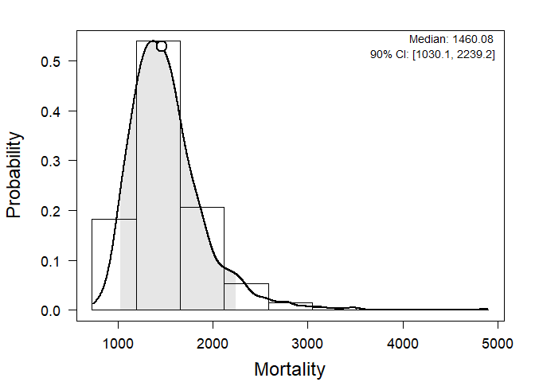

```r
plot(Mhat)
```

Mortality estimates may be partitioned or split into desired categories, such as species, season, or turbine type. Splits may be performed according to characteristics of the carcasses or where they were found (e.g., species, turbine or other variable found in `data_CO`) or when they were found (e.g., season or other variable associated with search schedule and found in `data_SS`, or a vector of specific times).

Mortality by `Species` (a CO split because it is a column in the CO file):

```r
M_species <- calcSplits(M = Mhat, split_CO = "Species", data_CO = data_CO)
summary(M_species)
```

```
#>     X        5%       25%       50%       75%        95%
#> BA 42 561.99570 697.24682 820.06018 988.90168 1284.71595
#> BB 14 189.75151 271.14240 347.72692 447.05644  652.84809
#> BC  9  69.63661 114.33633 151.78800 202.72047  296.85181
#> BD  5  27.74551  58.50035  85.24975 121.66288  193.71199
#> BE  1   1.00000   1.00000  14.30777  25.96535   46.89764
#> attr(,"CL")
#> [1] 0.9
#> attr(,"vars")
#> [1] "Species"
#> attr(,"type")
#> [1] "CO"
#> attr(,"class")
#> [1] "splitSummary"
```

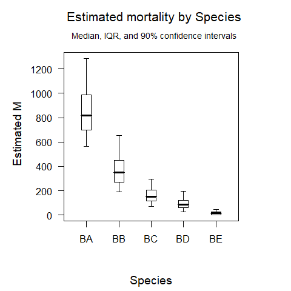

```r
plot(M_species)
```

Mortality estimates may also be split by temporal variables that are represented as columns in `data_SS` or as numeric vectors spanning the monitoring season (from day 0 to length of monitoring season). If several temporal splits are to be calculated, creating a specially formatted `prepSS` object for the search schedule can streamline the calculations.

```r
SSdat <- prepSS(data_SS)
```

Mortality by `Season` (an SS split because it is a column in the SS file):

```r
M_season <- calcSplits(M = Mhat, split_SS = "Season", data_SS = SSdat,
  split_CO = NULL,  data_CO = data_CO)
summary(M_season)
```

```
#>               X        5%      25%      50%      75%       95%
#> spring 18.10538 307.28436 445.7743 587.4128 778.5566 1255.5490
#> summer 10.16162  92.90686 157.0354 205.4157 267.7957  391.2335
#> fall   42.73300 422.65705 536.4184 618.5544 726.5111  921.8572
#> attr(,"CL")
#> [1] 0.9
#> attr(,"vars")
#> [1] "Season"
#> attr(,"type")
#> [1] "SS"
#> attr(,"times")
#> [1]   0  60 130 200
#> attr(,"class")
#> [1] "splitSummary"
```

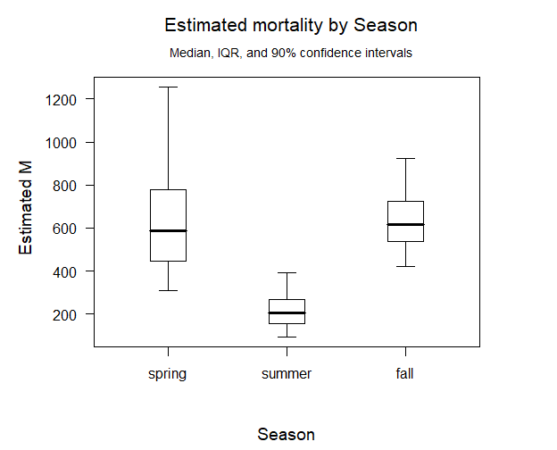

```r
plot(M_season)
```

Mortality by month (a temporal split that spans the monitoring period):

```r
M_month <- calcSplits(M = Mhat, split_time = seq(0, max(SSdat$days), by = 28),
  data_SS = SSdat, data_CO = data_CO)
summary(M_month)
```

```
#>             X         5%       25%       50%      75%      95%
#> 28   6.257583  87.491617 152.39761 222.60817 322.5496 571.3611
#> 56  11.713295 168.756967 254.53087 349.03225 478.3012 785.1703
#> 84   2.121836   2.121836  34.18265  66.03484 106.5027 199.4422
#> 112  4.570143  23.393471  49.85770  74.03236 101.8694 163.8731
#> 140 10.042429  73.339240 115.78569 143.12471 177.1878 238.5340
#> 168 27.842905 267.336851 351.60254 416.80881 496.2453 628.2497
#> 196  8.451810  51.167158  85.18927 113.84717 149.6160 205.3721
#> 200  0.000000   0.000000   0.00000   0.00000   0.0000   0.0000
#> attr(,"CL")
#> [1] 0.9
#> attr(,"vars")
#> [1] "time"
#> attr(,"type")
#> [1] "time"
#> attr(,"times")
#> [1]   0  28  56  84 112 140 168 196 200
#> attr(,"class")
#> [1] "splitSummary"
```

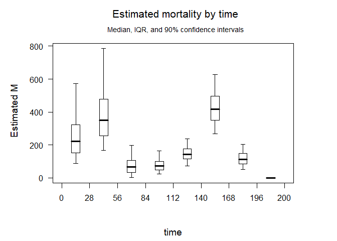

```r
plot(M_month)
```

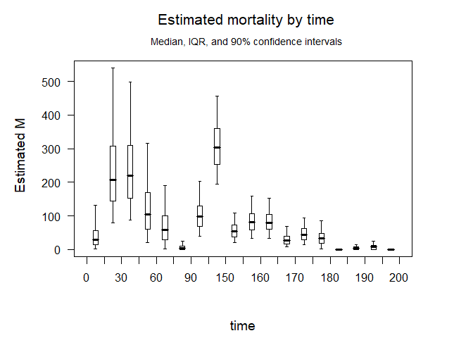

```r
M_various_times <- calcSplits(M = Mhat,
  split_time = c(seq(0, 90, by = 15), 120, 150, seq(155, 200, by = 5)),
  data_SS = SSdat, data_CO = data_CO)
plot(M_various_times)
```

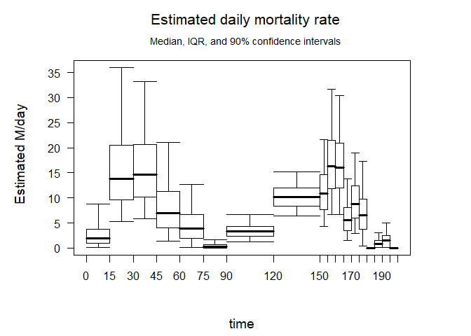

```r
plot(M_various_times, rate = TRUE)
```

Finally, splits can be calculated for combinations of splitting covariates, like species by season or species group by turbine type. No more than two splitting covariates may be used in one call to `calcSplits` and at most one temporal split may be used (whether it is an SS split or a vector of times).

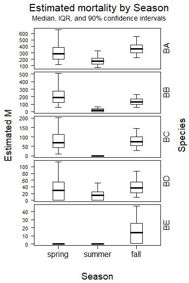

```r
M_species_by_season <- calcSplits(M = Mhat,
  split_CO = "Species", data_CO = data_CO,
  split_SS = "Season", data_SS = SSdat)
plot(M_species_by_season)
```

## Example 2: Estimating Bird and Bat Mortality from Searches on Varied Ground

Thorough searches out to a radius of 60 m from each turbine were conducted at 23 out of 100 turbines. The searched area was divided into three visibility classes (`RP`, `M`, `D`) according the difficulty of finding carcasses.

Searcher efficiency and carcass persistence would be expected to vary with carcass size (sparrow, eagle, bat), ground characteristics (road & pad, cleared field, vegetation type), season, etc. In this example, we perform a full analysis of scenario with four classes of carcass (`lrg`, `med`, `sml`, and `bat`), three visibility classes (difficult = `D`, moderate = `M`, and road & pad = `RP`), and three seasons (`spring`, `summer`, and `fall`).

The required data is stored in `wind_cleared`, a list of data frames with results for searcher efficiency (`SE`) and carcass persistence trials (`CP`), search schedules for all turbines (`SS`), the search coverage or density weighted proportion (`DWP`) of area searched at each turbine (i.e., the fraction of carcasses expected to fall in the search plots), and carcass observation (`CO`) data.

Load the full data set into R:

```r
data(wind_cleared)
names(wind_cleared)
```

```
#> [1] "SE"  "CP"  "SS"  "DWP" "CO"
```

To streamline the notation, extract the data from the `wind_cleared` list into its components:

```r
data_SE <- wind_cleared$SE
data_CP <- wind_cleared$CP
data_SS <- wind_cleared$SS
data_DWP <- wind_cleared$DWP
data_CO <- wind_cleared$CO
```

### Searcher Efficiency and Carcass Persistence Trials

```r
head(data_SE)
```

```
#>   pkID Size Season Visibility s1 s2 s3 s4 s5
#> 1  pk1  bat spring         RP  0 NA NA NA NA
#> 2  pk2  bat spring         RP  0  0 NA NA NA
#> 3  pk3  bat spring         RP  1 NA NA NA NA
#> 4  pk4  bat spring         RP  1 NA NA NA NA
#> 5  pk5  bat spring         RP  0 NA NA NA NA
#> 6  pk6  bat spring         RP  1 NA NA NA NA
```

```r
head(data_CP)
```

```
#>   cpID Size Season Visibility LastPresent FirstAbsent
#> 1  cp1  bat spring         RP        0.00        0.93
#> 2  cp2  bat spring         RP        0.98        1.97
#> 3  cp3  bat spring         RP        0.00        1.01
#> 4  cp4  bat spring         RP       13.99       21.13
#> 5  cp5  bat spring         RP        0.00        1.17
#> 6  cp6  bat spring         RP       20.95       27.97
```

### Searcher Efficiency Modeling

With 36 combinations of covariate levels (3 visibilities x 3 seasons x 4 sizes) and two parameters (`p` and `k`), the number of possible models to consider for searcher efficiency is unwieldy using simple calls to `pkm`, but `pkm` has powerful model building and model selection capabilities that can be accessed via the arg list: `allCombos` and `sizeCol`, which are discussed below.

When `allCombos = TRUE`, `pkm` fits the set of submodels of the given covariate combinations, including the full model, the null model, and everything in between. For example, if the parameter models are `p ~ Visibility * Season` and `k ~ Visibility`, `pkm` with `allCombos = TRUE` would fit all combinations of possible `p` models (`p ~ Visibility * Season`, `p ~ Visibility + Season`, `p ~ Visibility`, `p ~ Season`, and `p ~ 1`) and possible `k` models (`k ~ Visibility` and `k ~ 1`), or 10 models in all.

Carcasses in different size classes would be expected to have different searcher efficiency and carcass persistence parameters and would even be likely to be affected by covariates in different ways. When analyzing data with carcasses in different size classes, it is recommended that separate CP and SE models be fit for size classes separately. This can be accomplished using the `sizeCol` argument in `pkm` and `cpm`, where `sizeCol` gives the name of the column that gives the carcass size classes in `data_SE`.

```r
pkModels <- pkm(p ~ Visibility * Season, k ~ Visibility * Season, data = data_SE,
  allCombos = TRUE, sizeCol = "Size")
class(pkModels)
```

```
#> [1] "pkmSetSize" "list"
```

```r
names(pkModels)
```

```
#> [1] "bat" "lrg" "med" "sml"
```

When `allCombos = TRUE` and `sizeCol` is defined, `pkm` returns a list of sets of models for each size class. The sets of models for each size class include the full spectrum of models that can be constructed using simple combinations of the covariates.

```r
names(pkModels[["sml"]])
```

```
#>  [1] "p ~ Visibility * Season; k ~ Visibility * Season" "p ~ Visibility + Season; k ~ Visibility * Season"
#>  [3] "p ~ Season; k ~ Visibility * Season"              "p ~ Visibility; k ~ Visibility * Season"
#>  [5] "p ~ 1; k ~ Visibility * Season"                   "p ~ Visibility * Season; k ~ Visibility + Season"
#>  [7] "p ~ Visibility + Season; k ~ Visibility + Season" "p ~ Season; k ~ Visibility + Season"
#>  [9] "p ~ Visibility; k ~ Visibility + Season"          "p ~ 1; k ~ Visibility + Season"
#> [11] "p ~ Visibility * Season; k ~ Season"              "p ~ Visibility + Season; k ~ Season"
#> [13] "p ~ Season; k ~ Season"                           "p ~ Visibility; k ~ Season"
#> [15] "p ~ 1; k ~ Season"                                "p ~ Visibility * Season; k ~ Visibility"
#> [17] "p ~ Visibility + Season; k ~ Visibility"          "p ~ Season; k ~ Visibility"
#> [19] "p ~ Visibility; k ~ Visibility"                   "p ~ 1; k ~ Visibility"
#> [21] "p ~ Visibility * Season; k ~ 1"                   "p ~ Visibility + Season; k ~ 1"
#> [23] "p ~ Season; k ~ 1"                                "p ~ Visibility; k ~ 1"
#> [25] "p ~ 1; k ~ 1"
```

```r
class(pkModels[["sml"]])
```

```
#> [1] "pkmSet" "list"
```

To estimate mortality, one model for each size class must be selected from the long list of models fit. GenEst provides several tools for guiding the selection. First, the models can be listed by AICc, which gives a score for the quality of the model for the given data. Complicated models that use many parameters may fit the data more closely than a simpler model but are penalized because of their complexity and relative instability. The scores have meaning only in comparison with other models’. AICc provides a rough but useful guide for model selection, but should in no way be relied upon as definitive. Its utility is in identifying relatively poor models and in narrowing the choice of plausible models to a manageable number.

The `aicc` function lists the fitted models in order of ${\small \Delta}$AICc for each size class (if applicable). For this discussion, we will focus on `sml` only, but for a full analysis, all size classes would need to be similarly analyzed.

```r
aicc(pkModels[["sml"]])
```

```
#>                  p Formula               k Formula   AICc ΔAICc
#> 24          p ~ Visibility                   k ~ 1 318.55  0.00
#> 19          p ~ Visibility          k ~ Visibility 319.69  1.14
#> 14          p ~ Visibility              k ~ Season 321.42  2.87
#> 21 p ~ Visibility * Season                   k ~ 1 321.53  2.98
#> 22 p ~ Visibility + Season                   k ~ 1 322.17  3.62
#> 16 p ~ Visibility * Season          k ~ Visibility 322.98  4.43
#> 17 p ~ Visibility + Season          k ~ Visibility 323.14  4.59
#> 9           p ~ Visibility k ~ Visibility + Season 323.44  4.89
#> 11 p ~ Visibility * Season              k ~ Season 323.97  5.42
#> 12 p ~ Visibility + Season              k ~ Season 324.33  5.78
#> 7  p ~ Visibility + Season k ~ Visibility + Season 326.33  7.78
#> 6  p ~ Visibility * Season k ~ Visibility + Season 326.51  7.96
#> 4           p ~ Visibility k ~ Visibility * Season 327.98  9.43
#> 2  p ~ Visibility + Season k ~ Visibility * Season 331.07 12.52
#> 1  p ~ Visibility * Season k ~ Visibility * Season 333.47 14.92
#> 20                   p ~ 1          k ~ Visibility 339.51 20.96
#> 10                   p ~ 1 k ~ Visibility + Season 342.41 23.86
#> 18              p ~ Season          k ~ Visibility 342.74 24.19
#> 8               p ~ Season k ~ Visibility + Season 344.10 25.55
#> 25                   p ~ 1                   k ~ 1 346.45 27.90
#> 5                    p ~ 1 k ~ Visibility * Season 347.47 28.92
#> 15                   p ~ 1              k ~ Season 347.66 29.11
#> 23              p ~ Season                   k ~ 1 350.35 31.80
#> 13              p ~ Season              k ~ Season 350.44 31.89
#> 3               p ~ Season k ~ Visibility * Season 350.49 31.94
```

Preference should normally be given to models with ${\small \Delta}$AICc less than 6 or 7. Models with differences of less than 3 or 4 are generally considered indistinguishable by this measure. Choices among such models should be based on other criteria.

Diagnostic plots can be used to identify potential problems with model fits and to help distinguish between models with similar AICc scores. The `plot` function is defined for `pkm` (one model) and `pkmSet` (set of models for a given size class) objects. For example, `plot(pkModels[["sml"]][[1]])` would produce the single figure for the first model for the `sml` size class. `plot(pkModels[["sml"]])` would create plots for each model fit for the `sml` size class. To plot a specific single model from the full set, use the `specificModel` argument. For example, diagnostic plots for the model with the lowest AICc score are shown below:

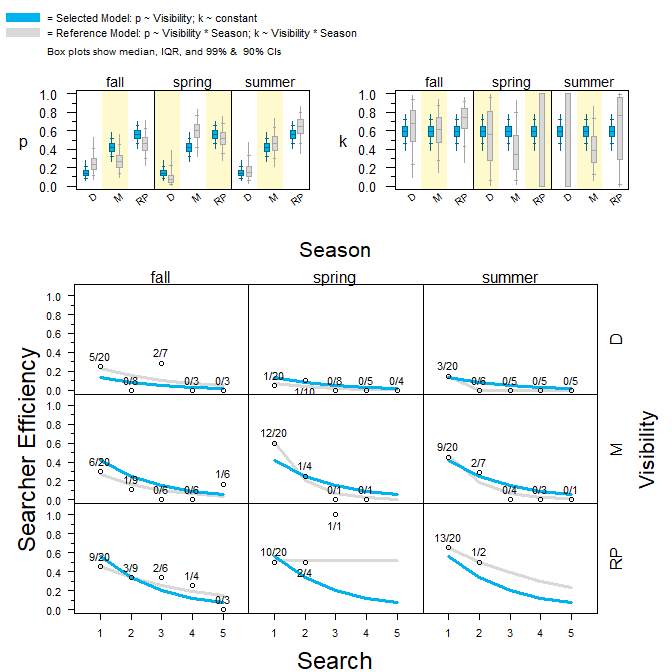

```r
plot(pkModels[["sml"]], specificModel = "p ~ Visibility; k ~ 1")
```

The top row shows box plots of estimated `p` and `k` parameters for all cells (i.e., combinations of covariate levels, like `D.fall` for difficult visibility in the fall) for both the selected model (blue) and the full model (gray). With the full model, the fits for each cell are based solely on data from that specific cell. The advantage is that each cell’s estimates are untainted by data from other cells. The disadvantage is that the sample size for each estimate is relatively small and the error bars large. In the reduced models, estimates for one cell borrow strength from estimates in related cells. This gives smaller error bars but can lead to errors if the model structure does not properly reflect the dependence of searcher efficiency parameters on cell characteristics.

In the figure, the estimates of `p` from the selected model are markedly less variable than the estimates from the full model, while the locations of the boxes are very similar for the two models. Thus, this selected model (the one with the lowest AICc) appears to be an improvement over the full cell model for estimating `p`.

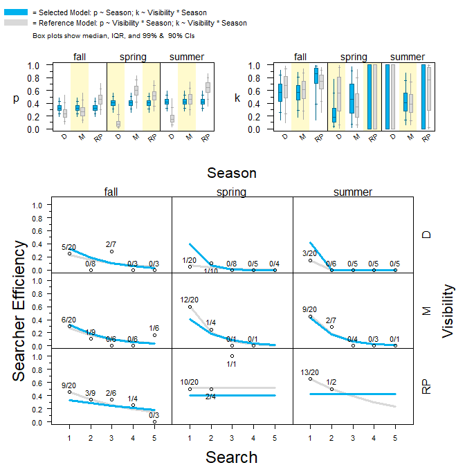

```r
plot(pkModels[["sml"]], specificModel = "p ~ Season; k ~ Visibility * Season")
```

A similar model selection exercise gives the same form of model (`p ~ Visibility; k ~ 1`) for large birds, medium birds, and bats. These can all be collated into a list for later analysis of detection probabilities and mortality rates.

```r
pkMods <- list(
  sml = pkModels[["sml"]][["p ~ Visibility; k ~ 1"]],
  med = pkModels[["med"]][["p ~ Visibility; k ~ 1"]],
  lrg = pkModels[["lrg"]][["p ~ Visibility; k ~ 1"]],
  bat = pkModels[["bat"]][["p ~ Visibility; k ~ 1"]]
)
```

### Carcass Persistence Modeling

The work flow for carcass persistence modeling is similar to that for searcher efficiency except that in addition to selecting covariates for two different parameters (location = `l` and scale = `s`), there are four model forms to choose from: Weibull, lognormal, loglogistic, and exponential.

```r
cpModels <- cpm(
  l ~ Visibility * Season, s ~ Visibility * Season,
  data = data_CP, left = "LastPresent", right = "FirstAbsent",
  dist = c( "weibull", "lognormal", "loglogistic", "exponential"),
  allCombos = TRUE, sizeCol = "Size"
)
```

The list of models is long:

```r
lapply(aicc(cpModels), nrow)
```

```
#> $bat
#> [1] 80
#>
#> $lrg
#> [1] 80
#>
#> $med
#> [1] 80
#>
#> $sml
#> [1] 80
```

```r
aicc(cpModels[["sml"]])
```

```
#>    Distribution        Location Formula           Scale Formula   AICc ΔAICc
#> 25      weibull                   l ~ 1                   s ~ 1 780.00  0.00
#> 24      weibull          l ~ Visibility                   s ~ 1 780.16  0.16
#> 15      weibull                   l ~ 1              s ~ Season 780.38  0.38
#> 19      weibull          l ~ Visibility          s ~ Visibility 780.97  0.97
#> 20      weibull                   l ~ 1          s ~ Visibility 781.32  1.32
#> 10      weibull                   l ~ 1 s ~ Visibility + Season 782.00  2.00
#> 14      weibull          l ~ Visibility              s ~ Season 782.04  2.04
#> 22      weibull l ~ Visibility + Season                   s ~ 1 782.55  2.55
#> 74  loglogistic          l ~ Visibility                   s ~ 1 782.57  2.57
#> 21      weibull l ~ Visibility * Season                   s ~ 1 782.77  2.77
#> 49    lognormal          l ~ Visibility                   s ~ 1 782.84  2.84
#> 23      weibull              l ~ Season                   s ~ 1 782.88  2.88
#> 71  loglogistic l ~ Visibility * Season                   s ~ 1 783.06  3.06
#> 13      weibull              l ~ Season              s ~ Season 783.16  3.16
```

[output cut: 66 more lines]

It is not uncommon to see the fits for the exponential distribution at the bottom of the AIC list. The exponential distribution has only one parameter and does not have nearly as much flexibility as the others, which each have two-parameters. An implicit assumption of the exponential model is that the scavenging rate is constant, regardless of carcass age. When that assumption is not met, the exponential provides an inferior fit.

To compare among a set of cp models with plausible AICs, use, for example, `plot(cpModels[["sml"]])` to browse through all the models or `plot(cpModels[["sml"]][["dist: lognormal; p ~ Visibility; k ~ 1"]])` to view a single model specified by name. It can be seen from the AICc table (`aicc(cpModels[["sml"]])`) that the top 10 models according to AICc are:

```r
cp_smlCandidates <-
    names(cpModels[["sml"]])[c(25, 24, 15, 19, 20, 10, 14, 22, 74, 21)]
cp_smlCandidates
```

```
#>  [1] "dist: weibull; l ~ 1; s ~ 1"                   "dist: weibull; l ~ Visibility; s ~ 1"
#>  [3] "dist: weibull; l ~ 1; s ~ Season"              "dist: weibull; l ~ Visibility; s ~ Visibility"
#>  [5] "dist: weibull; l ~ 1; s ~ Visibility"          "dist: weibull; l ~ 1; s ~ Visibility + Season"
#>  [7] "dist: weibull; l ~ Visibility; s ~ Season"     "dist: weibull; l ~ Visibility + Season; s ~ 1"
#>  [9] "dist: loglogistic; l ~ Visibility; s ~ 1"      "dist: weibull; l ~ Visibility * Season; s ~ 1"
```

These can be compared in graphs as follows:

```r
plot(cpModels[["sml"]], specificModel = cp_smlCandidates)
```

We’re looking for a good fit between the selected model and the data in as many cells as possible. The first several models among the `cp_smlCandidates` seems to provide a reasonably good fit in all cells, although there seems to be a trade-off between fitting the RP.spring cell well or fitting the RP.summer cell well. `Visibility` occurs frequently in the top models, while `Season` appears more frequently in the bottom models. This indicates that `Season` is probably not a strong predictor of carcass persistence, while `Visibility` is.

Selecting the top AICc model for use in mortality estimation:

```r
cp_sml <- cpModels[["sml"]][[cp_smlCandidates[1]]]
```

Following a similar model selection process for the other size classes, we select the following:

```r
cp_med <- cpModels[["med"]][["dist: weibull; l ~ Visibility; s ~ Season"]]
cp_lrg <- cpModels[["lrg"]][["dist: exponential; l ~ Visibility + Season; NULL"]]
cp_bat <- cpModels[["bat"]][["dist: weibull; l ~ Visibility + Season; s ~ 1"]]
```

NOTE: For large carcasses, the exponential distribution was at the top of the AICc list. The exponential requires only one parameter (`l`), so no scale parameter is provided in the model.

Again, we collate the models into a list for later analysis of detection probabilities and mortality rates.

```r
cpMods <- list(
  sml = cp_sml,
  med = cp_med,
  lrg = cp_lrg,
  bat = cp_bat
)
```

### Mortality Estimation

Each carcass’s contribution to the total mortality in each search interval is estimated using the `estM` function. The function call is largely similar that used in the simple scenario discussed in example 1. However, there are some important differences. First, `model_SE` and `model_CP` are lists of models, one element for each size class. In addition, the name of the size class variable is provided as `sizeCol = "Size"`. Finally, the `frac` argument represents the sampling fraction or the fraction of carcasses expected to fall at the units that were searched. In this example, 23 out of 100 turbines were searched, and `frac` is set equal to 0.23 under the assumption that the mortality rates at the unsearched turbines did not differ substantially from the rates at the searched turbines.

```r
Mhat <- estM(nsim = 1000, data_CO = data_CO, data_SS = data_SS, frac = 0.23,
  data_DWP = data_DWP, model_SE = pkMods, model_CP = cpMods,
  sizeCol = "Size", unitCol = "Turbine", COdate = "DateFound")

summary(Mhat)
```

```
#>  median      5%     95%
#> 1916.46 1483.34 2483.46
```

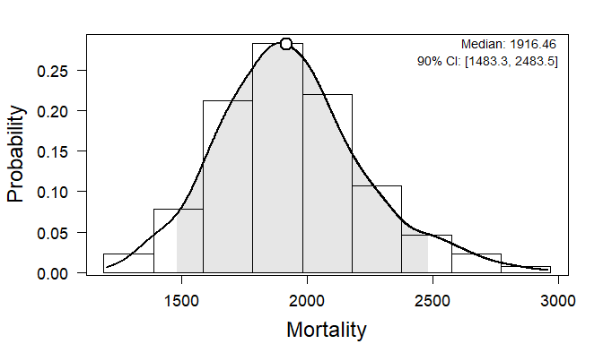

```r
plot(Mhat)
```

This estimate is for the total number of fatalities among all size classes combined, from hummingbirds and bats to eagles and may be too vague to be very useful. Fortunately, mortality estimates may be partitioned or split into desired categories, such as species, size, or season. Splits may be performed according to characteristics of the carcasses or where they were found (e.g., species, turbine or other variable found in `data_CO`) or when they were found (e.g., season or other variable associated with search schedule and found in `data_SS`, or a vector of specific times).

Carcasses were categorized not only by size but also by species, species group, the type of turbine they were found at, the visibility class of the ground where they were found, and distance from nearest turbine.

Although species groups may extend across different size classes (e.g., `raptors` could include kestrels, red-tailed hawks, and golden eagles; `passerines` could include sparrows and ravens), splits according to species group can easily be accomplished:

```r
M_speciesGroup <- calcSplits(M = Mhat,
  split_CO = "SpeciesGroup",  data_CO = data_CO)
summary(M_speciesGroup)
```

```
#>       X        5%       25%        50%        75%       95%
#> bat0  4  16.24120  41.68399   62.86273   85.55249  129.0495
#> bat1 49 804.49620 981.44825 1110.85088 1246.64839 1527.2471
#> brd1 19 302.19653 424.59709  519.07928  637.02494  864.5506
#> brd2 10  67.02341 104.28074  138.98593  172.36072  233.9164
#> brd3  5  20.20642  37.43876   53.14112   70.31839  100.5767
#> attr(,"CL")
#> [1] 0.9
#> attr(,"vars")
#> [1] "SpeciesGroup"
#> attr(,"type")
#> [1] "CO"
#> attr(,"class")
#> [1] "splitSummary"
```

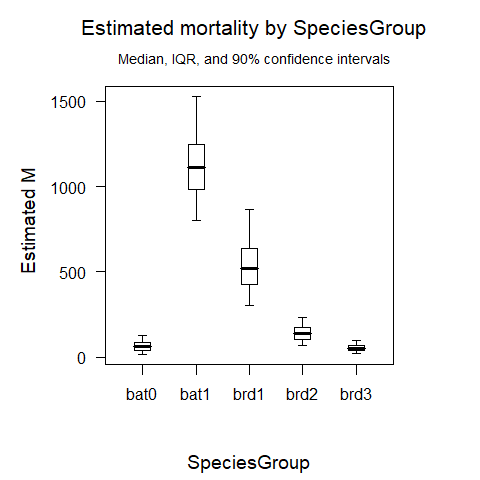

```r
plot(M_speciesGroup)
```

Split by species and season:

```r
M_speciesseason <- calcSplits(M = Mhat,
  split_CO = "Species",  data_CO = data_CO, split_SS = "Season", data_SS = data_SS)
summary(M_speciesseason)
```

```
#> $BA
#>             X        5%       25%      50%      75%      95%
#> spring  7.000  76.29369 143.88691 196.3865 263.4324 362.3624
#> summer  3.349  15.51143  49.49931  78.5921 112.6984 173.9983
#> fall   22.651 278.15381 350.50173 419.0914 497.6210 627.5099
#>
#> $BB
#>            X       5%      25%       50%       75%       95%
#> spring 3.000 27.29299 74.94659 118.61772 169.30998 274.51683
#> summer 1.162  1.16200  1.16200  25.84782  48.50449  90.50564
#> fall   6.838 46.77286 90.94127 126.24433 163.85150 231.00670
#>
#> $BC
#>            X       5%      25%      50%      75%       95%
#> spring 1.024 1.024000  1.02400 36.26280 67.05830 116.85445
#> summer 0.979 0.979000  0.97900 22.30766 37.13601  64.88834
#> fall   2.997 8.709672 27.21028 48.02210 73.48793 115.26898
#>
#> $BD
#>            X    5%      25%      50%    75%      95%
#> spring 0.000 0.000  0.00000  0.00000  0.000  0.00000
#> summer 0.002 0.002  0.00200  0.00200  0.002  0.00200
#> fall   1.998 1.998 11.74564 27.16038 45.259 77.75083
#>
#> $BE
#>        X 5%     25%      50%      75%      95%
#> spring 0  0  0.0000  0.00000  0.00000  0.00000
#> summer 0  0  0.0000  0.00000  0.00000  0.00000
#> fall   2  2 15.9172 31.80083 49.39509 81.22952
#>
#> $LA
#>        X 5%      25%      50%      75%      95%
#> spring 2  2 9.396080 18.50725 27.81603 39.86108
#> summer 0  0 0.000000  0.00000  0.00000  0.00000
#> fall   2  2 8.888873 19.90504 30.01280 48.62278
#>
#> $LB
#>        X 5% 25%      50%      75%      95%
#> spring 1  1   1 10.12099 12.23168 30.38922
#> summer 0  0   0  0.00000  0.00000  0.00000
```

[output cut: 87 more lines]

```
#>              X       5%      25%       50%       75%      95%
#> spring 3.04875 20.61098 62.67863 105.80862 156.01118 260.1824
#> summer 1.95125  1.95125 31.89793  58.47863  96.00748 162.1811
#> fall   0.00000  0.00000  0.00000   0.00000   0.00000   0.0000
#>
#> attr(,"CL")
#> [1] 0.9
#> attr(,"vars")
#> [1] "Season"  "Species"
#> attr(,"type")
#> [1] "SS" "CO"
#> attr(,"times")
#> [1]   0  60 130 200
#> attr(,"class")
#> [1] "splitSummary"
```

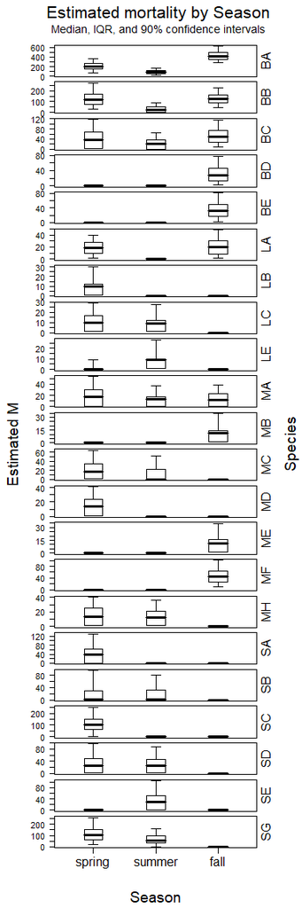

```r
plot(M_speciesseason)
```

There are so many vertical panels that it is difficult to glean any useful information out of the graph. However, the panels may be transposed and graphed for better interpretability:

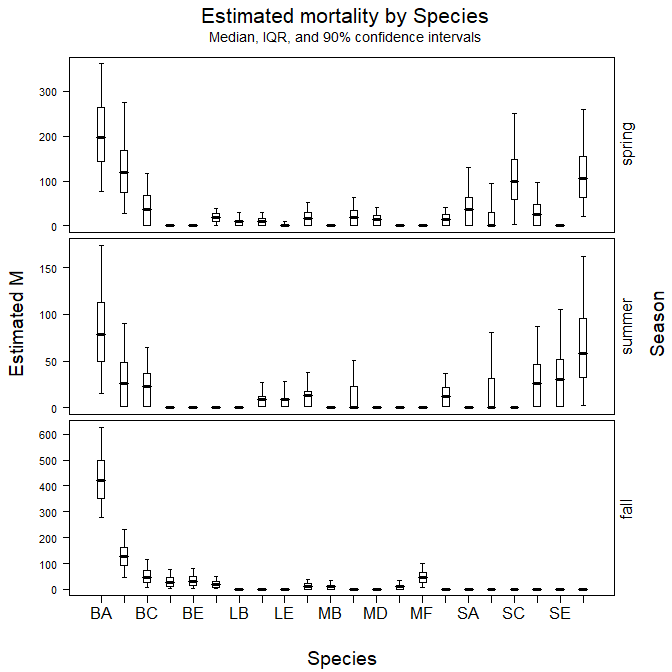

```r
plot(transposeSplits(M_speciesseason))
```